# Time Series Exam 1

## Question 1 (22 points)

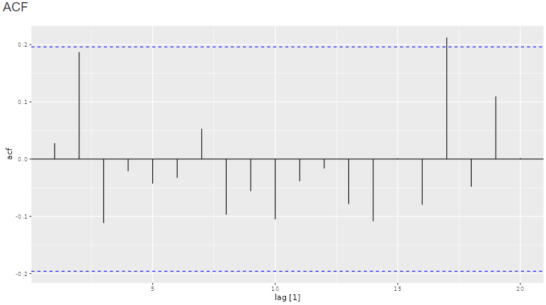

Figure 1: Monthly ACF1

#### A) Give the name of the plot in Figure 1 (2 points)

**Answer**

#### B) Explain what this plot shows. What do the values in the axis represent, what do the lines mean? (10 points)

**Answer**

#### C) Describe the characteristics of the time series that would have generated this plot.(10 points)

**Answer**

## Question 2 (20 points)

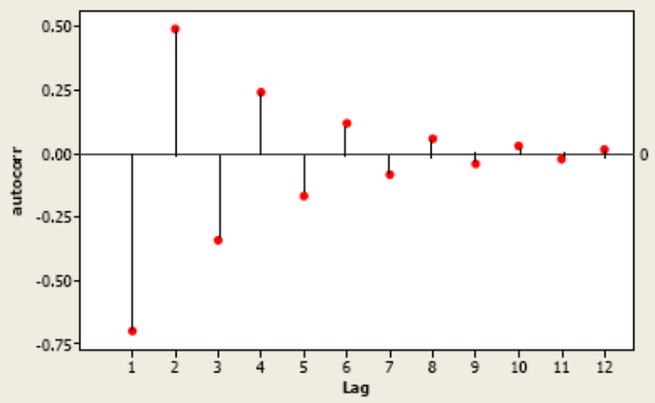

Figure 2: Monthly ACF2

#### A) Sketch a time series that might lead to a plot like Figure 2. You can do this by hand, take a picture, then render the document with your picture.(10 points)

**Answer**

#### B) Describe the theoretical reasoning behind your sketch. Please demostrate your understanding of the figure and the underlying random process.(10 points)

**Answer**

## Question 3 (30 points)

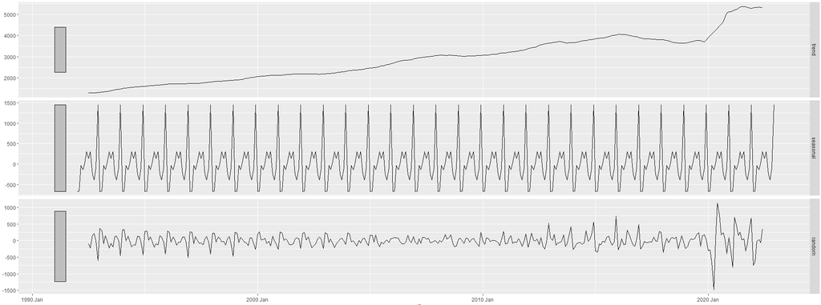

Figure 3: Decomposition 1

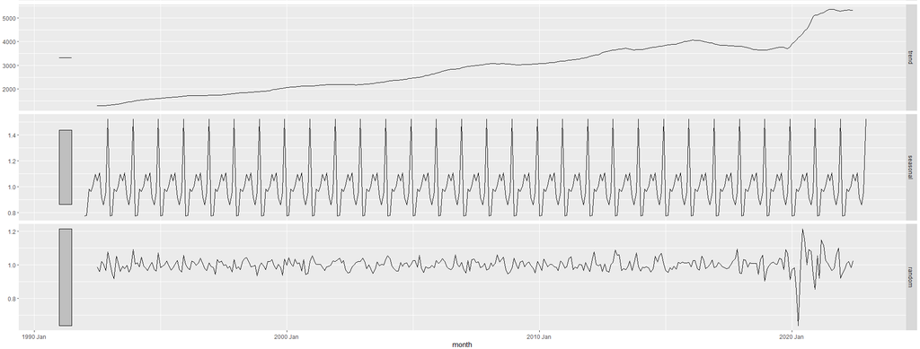

Figure 4: Decomposition 2

Figure 3 and Figure 4 represent either the additive or multiplicative decompositions of the same time series.

#### A) Which of these figures is the additive decomposition? Justify your answer (10 points)

**Answer**

#### b) Which of the decompositions is more appropriate for the time series? Please justify your position. *Hint: Decompose an additive series using the wrong algorithm. Then decompose a multiplicative series using the wrong algorithm.* (20 points)

**Answer**

## Question 4 (14 points)

#### A) What is the difference between a stochastic and a deterministic trend in a time series? (4 points)

**Answer**

#### b) Why is the type of trend important for the analysis and forecasting of time series? (10 points)

**Answer**

### Question 5 (9 points)

Read in the following data file

```r
temp1 <- rio::import("https://github.com/byuistats/timeseries/raw/master/exams/exam1/test1_winter24_data1.csv")

knitr::kable(temp1)
```

| date | trend | seasonal | random |
| --- | --- | --- | --- |
| Jan-20 | 10.0 | 5.5 | 0.0 |
| Apr-20 | 10.1 | 1.5 | 0.1 |
| Jul-20 | 10.3 | -4.0 | 0.1 |
| Oct-20 | 10.3 | -2.0 | 0.2 |
| Jan-21 | 10.7 | 5.5 | 5.1 |
| Apr-21 | 10.9 | 1.5 | 0.0 |
| Jul-21 | 11.2 | -4.0 | -6.1 |
| Oct-21 | 11.5 | -2.0 | -4.0 |
| Jan-22 | 11.6 | 5.5 | -0.2 |
| Apr-22 | 11.9 | 1.5 | 0.1 |
| Jul-22 | 12.0 | -4.0 | -0.4 |
| Oct-22 | 12.3 | -2.0 | -0.4 |
| Jan-23 | 12.3 | 5.5 | 3.1 |
| Apr-23 | 12.7 | 1.5 | 0.3 |
| Jul-23 | 13.0 | -4.0 | 0.2 |
| Oct-23 | 13.2 | -2.0 | -0.1 |

#### A) What is the value of the times series in July 2021? (5 points)

**Answer**

#### B) What value would you use to forecast the seasonal value for January 2024? Please justify your answer (4 points)

**Answer**

### Question 6 (20 points)

#### A) Compare and contrast EWMA and Holt-Winters algorithms (20 points)

**Answer**

### Question 7 (25 points)

#### A) What is the difference between statistical and practical significance? (10 points)

**Answer**

#### B) Provide an example when a statistically significant result is not practically significant. You may use examples outside the context of this course. (15 points)

**Answer**